# Assignment 9

# [Q.N.11]Get the head of the saved scores of mtcars.pca and interpret carefully

```r
head(mtcars.pca$scores)
```

```
##                           PC1        PC2        PC3        PC4
## Mazda RX4         -0.27929417  0.8132290 -0.2877380 -0.2447853
## Mazda RX4 Wag     -0.26793045  0.6770476  0.1560073 -0.1664252
## Datsun 710        -0.96699807 -0.2263347 -0.2959516 -0.2110014
## Hornet 4 Drive    -0.09052843 -1.3699797 -0.4639869 -0.5984019
## Hornet Sportabout  0.66729435 -0.5743299 -1.4547534  0.2862895
## Valiant            0.02085807 -1.6956141  0.1574155 -1.6929588
```

The original ddataset is projected into four principal components.

# [Q.N.12] Get the head of the scores of first two components of mtcars.pca and intepret it carefully

```r
head(mtcars.pca_2$scores)
```

```
##                           PC1        PC2
## Mazda RX4         -0.27929417  0.8132290
## Mazda RX4 Wag     -0.26793045  0.6770476
## Datsun 710        -0.96699807 -0.2263347
## Hornet 4 Drive    -0.09052843 -1.3699797
## Hornet Sportabout  0.66729435 -0.5743299
## Valiant            0.02085807 -1.6956141
```

# [Q.N.13] Get biplot of these two component scores and interpret it carefully

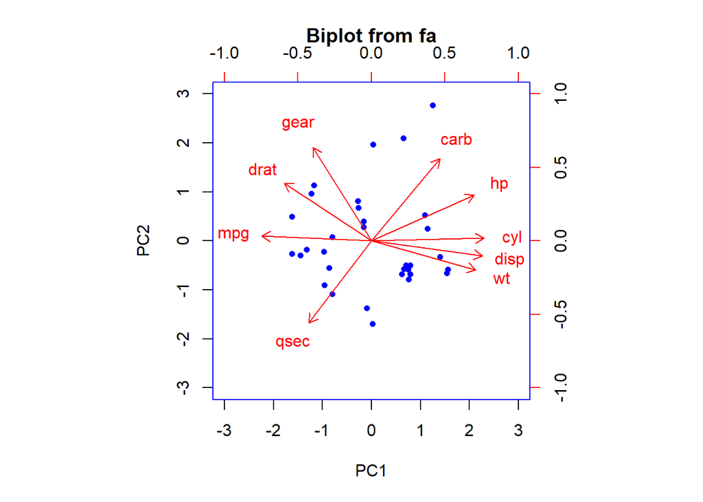

```r
biplot(mtcars.pca_2, col = c("blue", "red"))
```

Here we can observe that hp, cyl, disp and wt contribute to PC1 with higher values. And mpg which has negative loadings is in opposite direction to PC1 with higher values. Gear and carb has higher contribution to PC2 with positive values and qsec has negative value.

# [Q.N.14] Get dissimilar distance of all the variables of mtcars data as mtcars.dist

```r
#Distance calculation
mtcars.dist<- dist(mtcars.subset)
```

# [Q.N.15]Fit classical multi-dimensional scaling model with the mtcars.dist in 2-dimensional state as cars.mds.2d

```r
# Fitting classical two- dimensional scaling model
cars.mds.2d<-cmdscale(mtcars.dist)
summary(cars.mds.2d)
```

```
##        V1                V2
##  Min.   :-181.07   Min.   :-139.047
##  1st Qu.:-116.69   1st Qu.: -10.373
##  Median : -43.99   Median :   2.144
##  Mean   :   0.00   Mean   :   0.000
##  3rd Qu.: 132.85   3rd Qu.:  29.375
##  Max.   : 242.81   Max.   :  52.503
```

# [Q.N.16] Plot the cars.mds.2d and compare it with the biplot of mtcars.pca and interpret it carefully.

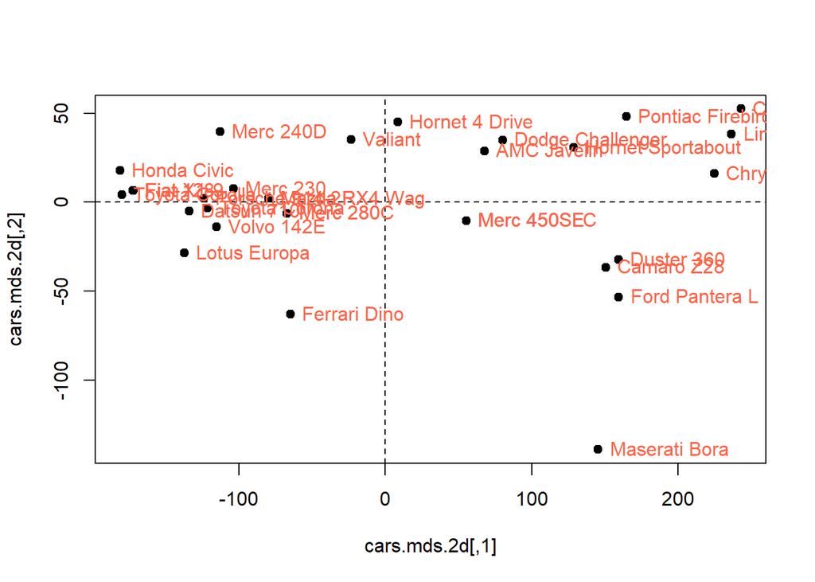

```r
plot(cars.mds.2d, pch = 19)
abline(h = 0, v = 0, lty =2)
mtcars.subset<-mtcars[, 1:2] %>% scale
text(cars.mds.2d, pos = 4, labels = rownames(mtcars.subset), col = "tomato")
```

# [Q.N.17] Fit classical multi-dimensional scaling model with the mtcars.dist in 3-dimensional state as cars.mds.3d

```r
#Fiting multi-dimensional scaling model with mtcars.dist in 3 - dimensional state
cars.mds.3d<-cmdscale(mtcars.dist, k = 3)
summary(cars.mds.3d)
```

```
##        V1                V2                 V3
##  Min.   :-181.07   Min.   :-139.047   Min.   :-6.8611
##  1st Qu.:-116.69   1st Qu.: -10.373   1st Qu.:-1.8374
##  Median : -43.99   Median :   2.144   Median : 0.8492
##  Mean   :   0.00   Mean   :   0.000   Mean   : 0.0000
##  3rd Qu.: 132.85   3rd Qu.:  29.375   3rd Qu.: 2.2806
##  Max.   : 242.81   Max.   :  52.503   Max.   : 5.0029
```

# [Q.N.18] Create a 3-d scatterplot of cars.mds.3d with type = “h”, pch=20 and lty.hplot=2 and interpret it carefully

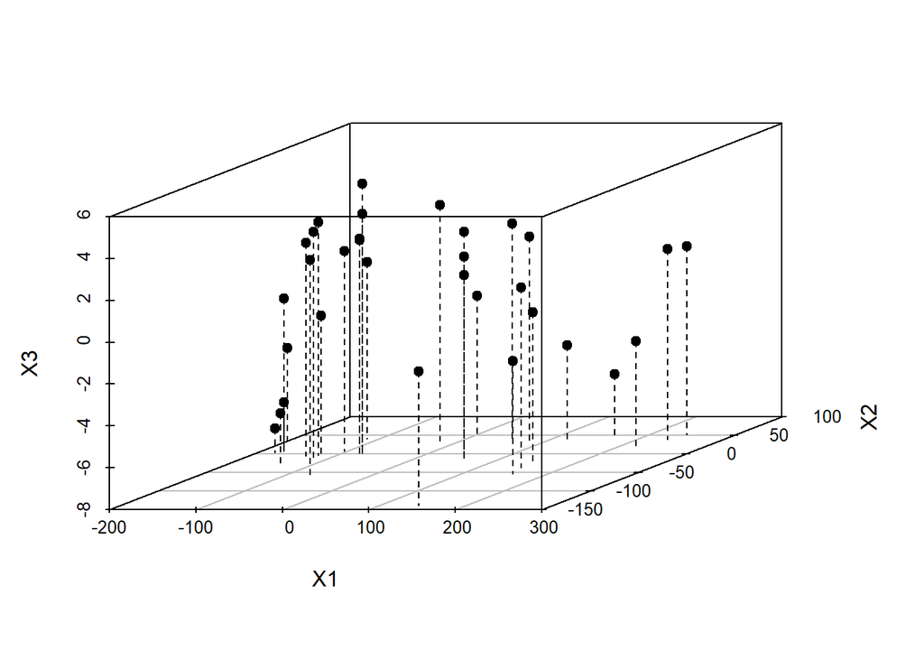

```r
library(scatterplot3d)
cars.mds.3d <- data.frame(cmdscale(mtcars.dist, k = 3))
scatterplot3d(cars.mds.3d, type = "h", pch = 19, lty.hplot = 2)
```

# [Q.N.19] Create a 3-d scatterplot of cars.mds.3d with type = “h”, pch=20, lty.hplot=2 and color=mtcars$cyl and interpret it carefully

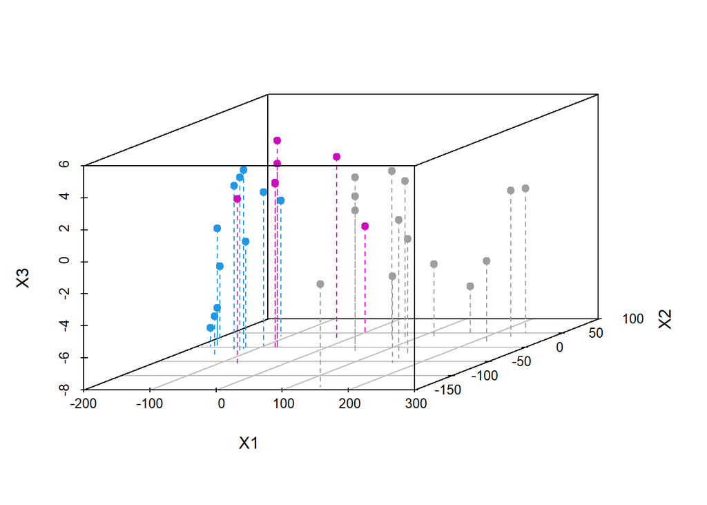

```r
library(scatterplot3d)
cars.mds.3d <- data.frame(cmdscale(mtcars.dist, k = 3))
scatterplot3d(cars.mds.3d, type = "h", pch = 19, lty.hplot = 2, color = mtcars$cyl)
```

We plotted the principal components in 3- dimensional scatter plot which is distinguished by color cyl. We can use higher dimensions by changing the k argument in the cmdscale() function to a higher value for eg. k = 3 for 3 dimensuon.

# [Q.N.20] Write a summary comparing PCA and MDS fits done above for mtcars data

`Solution`: The input to PCA is the original vectors in n-dimensional space. Similarly, input to MDS is the pairwise distances between points. PCA behaves as an algorithm but MDS is a visualization technique for any factor analysis. MDS applies PCA for the dimensionality reduction. For the mtcars, it shows that two or more but less than or equal to 5 latent features can be generated from the given dataset.